# The OSA miRs Database

# 1 Scientific Context

## 1.1 Introduction

The OSA miR database, a manually curated database, compiles experiment-supported evidence for differentially expressed microRNAs (miRNAs) in Obstructive Sleep Apnea (OSA). OSA is a sleep-related breathing disorder characterized by recurrent obstructions in the upper airways while breathing efforts persist. Each obstruction episode temporarily blocks (apneas) or reduces (hypopneas) airflow, resulting in surges in sympathetic activity and frequent arousals or microarousals during sleep. Despite being one of the most prevalent sleep disorders worldwide, the diagnosis and treatment is still difficult. Currently, the diagnosis involves a sleep study (type I to type III) that is expensive, labor-intensive, and time-consuming. Continuous Positive Airway Pressure (CPAP) is currently the first-line and most effective treatment. However, its efficacy is often challenged by low adherence rates and its effects on comorbid conditions have been questioned. Untreated OSA is associated with multiple health conditions, including hypertension, heart disease, metabolic diseases, cancer, neurodegenerative disorders, depression, and musculoskeletal disorders. The clinical community has reinforced the need for biomarkers for OSA diagnosis, patient stratification, and treatment response monitoring; however, to date, no biomarkers have been validated.

Short (≈ 21-25 nucleotides), single-stranded, non-coding RNAs, known as miRNAs, have been proposed as potential biomarkers in the context of several diseases. The main role of miRNAs is to regulate gene expression post-transcription. These ncRNAs interact with messenger RNAs (mRNAs) through complementary base pairing and promote translational repression or degradation, thereby influencing mRNAs translation and stability. Thus, miRNAs coordinate the expression of multiple genes and act as key regulators of multiple cellular and physiological processes in both health and disease. Several studies have been conducted to identify the miRNA signatures associated with OSA. The identification of dysregulated miRNAs and gene targets may provide relevant insights into the pathophysiology of OSA and its pleiotropic effects, with applications in the clinical management of this disease.

## 1.2 Key Points

In this context, we proposed mining the existing biomedical literature on dysregulated miRNAs in OSA to construct a unified and structured OSA miRNA database: the OSA miR database. Each entry in the database provides information on 13 items.

1. Name of the assessed miRNAs
2. Accession number
3. Observed change (up-or downregulated) or no change
4. Biological samples in which miRNA expression was evaluated
5. Collection time for biological samples
6. Cohort size
7. Study groups
8. Age of the study participants
9. Body mass index (BMI) of study participants
10. Apnea-Hypopnea Index (AHI) of the study participants
11. Comorbidities of the study participants
12. Correlations between the expression of the studied miRNAs and clinical measurements
13. Study reference

The compiled data on the OSA miR database constitute a valuable resource for catalyzing future research on OSA molecular mechanisms and identifying biomarkers for clinical application.

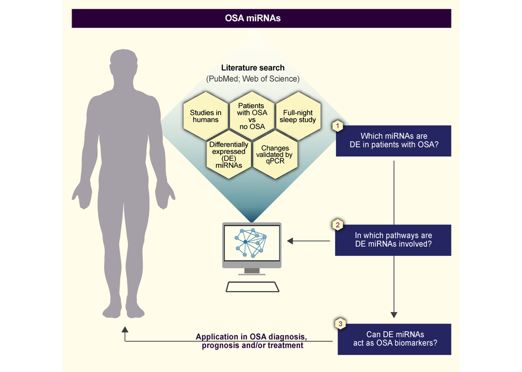

# 2 DataBase

| miRNA | Acession number | Change | Biological sample | Collection time | Cohort, size [n (M/F)] | Groups, size [n (M/F)] | Age (years ± SD) | BMI (kg/m2 ± SD) | AHI (events/hour of sleep) | Comorbidities | Correlations | Evaluated after treatment | Ref |
| --- | --- | --- | --- | --- | --- | --- | --- | --- | --- | --- | --- | --- | --- |
| hsa-let-7a-1-5p | MIMAT0000062 | NC | PBMCs | Morning | Adults, n = 65 (46/19) | With OSA, n = 45 (34/11) | OSA (48.5 ± ?) | OSA (26.4 ± 3.4) | OSA (54.8 ± 19.2) | H; DM; Heart disease; COPD; Depression | NR | N | 5 |
| hsa-let-7a-1-5p | MIMAT0000062 | NC | PBMCs | Morning | Adults, n = 65 (46/19) | Without OSA (Primary-snoring), n = 20 (12/8) | Primary-snoring (44.6 ± 12.6) | Primary-snoring (25.1 ± 3.6) | Primary-snoring (2.7 ± 1.8) | H; DM; Heart disease; COPD; Depression | NR | N | 5 |
| hsa-let-7a-1-5p | MIMAT0000062 | NC | PBMCs | Morning | Adults, n = 65 (46/19) | On CPAP treatment, n = 13 (11/2) | OSA-CPAP (50.6 ± 7.5) | OSA-CPAP (27.3 ± 2.9) | OSA-CPAP (62.5 ± 23.3) | H; DM; Heart disease; COPD; Depression | NR | N | 5 |
| hsa-let-7b-5p | MIMAT0000063 | D | UA skeletal muscle | NR | Adults, n = 20 (12/8) | With OSA, n = 10 (7/3) | OSA (35.21± 1.9*) | OSA (30.1 ± 1.1*) | OSA (72.4 ± 5.1*) | NR (TG; Excessive weight/ Obesity) | NR | N | 3 |
| hsa-let-7b-5p | MIMAT0000063 | D | UA skeletal muscle | NR | Adults, n = 20 (12/8) | Without OSA (Chronic tonsillitis), n = 10 (5/5) | Chronic tonsillitis (36.8 ± 2.0*) | Chronic tonsillitis (27.6 ± 1.3*) | Chronic tonsillitis (2.0 ± 1.2*) | NR (TG; Excessive weight/ Obesity) | NR | N | 3 |
| hsa-let-7d-5p | MIMAT0000065 | D | Serum | 8h | Adults, n = 45 (36/9) | With OSA, n = 15 (13/2) | OSA (43 ± 2.5*) | OSA (25.6 ± 0.4*) | OSA (47.4 ± 4.9*) | ? | NR | N | 8 |
| hsa-let-7d-5p | MIMAT0000065 | D | Serum | 8h | Adults, n = 45 (36/9) | Without OSA, n = 15 (11/4) | Non-OSA (43.4 ± 2.1*) | Non-OSA (24.6 ± 0.5*) | Non-OSA (4.5 ± 0.6*) | ? | NR | N | 8 |
| hsa-let-7d-5p | MIMAT0000065 | D | Serum | 8h | Adults, n = 45 (36/9) | With OSA + HT, n =15 (12/3) | OSA + HT (43.6 ± 2.3*) | OSA + HT (26.2 ± 0.6*) | OSA + HT (43.5 ± 5.2*) | ? | NR | N | 8 |
| hsa-let-7g-5p | MIMAT0000414 | D | UA skeletal muscle | NR | Adults, n = 20 (12/8) | With OSA, n = 10 (7/3) | OSA (35.21± 1.9*) | OSA (30.1 ± 1.1*) | OSA (72.4 ± 5.1*) | NR (TG; Excessive weight/ Obesity) | NR | N | 3 |
| hsa-let-7g-5p | MIMAT0000414 | D | UA skeletal muscle | NR | Adults, n = 20 (12/8) | Without OSA (Chronic tonsillitis), n = 10 (5/5) | Chronic tonsillitis (36.8 ± 2.0*) | Chronic tonsillitis (27.6 ± 1.3* | Chronic tonsillitis (2.0 ± 1.2*) | NR (TG; Excessive weight/ Obesity) | NR | N | 3 |

[output cut: 161 more lines]

*Footnote:* AHI: Apnea-Hypopnea Index; BMI: Body mass index; D: Down-regulated; DM: Diabetes mellitus; EVs: Extracellular Vesicles; FEV1: Forced expiratory volume in the first second; HC: COPD with chronic Hypoxia- ODI < 5; diurnal PaO2 < 60 mmHg; HCHI: Intermittent and Chronic Hypoxia: ODI> 15; diurnal PaO2 < 60 mmHg; HI: Intermittent Hypoxia -ODI > 15; diurnal PaO2 ≥ 60 mmHg; HT: Hypertension; iCIMT: Carotid intima-media thickness; Max: maximum; N: No; NC: No Change; NR: Not reported; PBMCs: Peripheral blood mononuclear cells; SpO2: Peripheral oxygen saturation; SaO2: Arterial Oxygen Saturation; TG: Triglycerides; U: Up-regulated; UA: Upper airway; Y: Yes; ?: Not clear; (-) inverse correlation; (+) direct correlation; *: SEM; #: median (interquartile range).

# 3 Methodology

The study protocol that guided this database was registered at the International Prospective Register of Systematic Reviews database (PROSPERO, https://www.crd.york.ac.uk/prospero/), with the title Differential Expression Of MicroRNAs In Obstructive Sleep Apnea: A Systematic Review And Pathway Analysis, on January 1st 2023 (ID: CRD42023386720). A manuscript with the methods originating from this database is currently under submission.

## 3.2 Search Strategy and Consulted Databases

The electronic search was conducted on June 20, 2022, without initial date restrictions, using the PubMed/Medline and Web of Science databases. We searched for terms related to OSA and miRNAs [(OSA OR Sleep Apnea or Sleep Apnoea OR Obstructive Sleep Apnea OR Obstructive Sleep Apnoea) AND (miRNAs OR miRs OR microRNAs OR small RNAs)], without language restrictions. Duplicates from the different databases were removed.

## 3.3 Study Selection Process

The identified studies were screened according to the defined inclusion and exclusion criteria based on the study title (Phase I) and abstract (Phase II). Full manuscripts of the selected studies were retrieved and assessed for eligibility (Phase III). Two independent reviewers performed all the phases of the study selection process. Any disagreement between the two independent reviewers at any of the study phases was resolved by discussion with a third reviewer if needed.

## 3.4 Data Collection and Analysis

Each study was summarized in terms of the study design, demographic, and clinical characteristics of the enrolled participants, and obtained results. We retrieved Differentially Expressed miRNAs reported in patients with OSA relative to control subjects from eligible studies. miRNAs were grouped based on the accession numbers obtained from miRBase. The data collection was performed by a single author. A second author cross-checked all the data and confirmed its accuracy. Any disagreement was resolved through discussion and the involvement of a third author. The obtained results were used to build an online database of OSA miRs on the GitHub platform.

## 3.5 Inclusion of New Studies

**Do you want to add your study to the OSA miRNA database?**  
Please contact us at sleepapneaid.cnc-at-gmail.com (replace *-at-* with @). We will analyze the study and update the database if the study is eligible.

# 4 References

1. Li J, Fan T, Li Y, et al. Effect and mechanism of miRNA on obstructive sleep apnea in children. Mater Express. 2020;10(3):404-411. doi:10.1166/MEX.2020.1646
2. Lacedonia D, Scioscia G, Palladino GP, et al. MicroRNA expression profile during different conditions of hypoxia. Oncotarget. 2018;9(80):35114. doi:10.18632/ONCOTARGET.26210
3. Hou J, Zhao L, Yan J, et al. MicroRNA expression profile is altered in the upper airway skeletal muscle tissue of patients with obstructive sleep apnea-hypopnea syndrome. J Int Med Res. 2019;47(9):4163-4182. doi:10.1177/0300060519858900
4. Li K, Wei P, Qin Y, Wei Y. MicroRNA expression profiling and bioinformatics analysis of dysregulated microRNAs in obstructive sleep apnea patients. Medicine (Baltimore). 2017;96(34):e7917. doi:10.1097/MD.0000000000007917
5. Chen YC, Hsu PY, Su MC, et al. MicroRNA Sequencing Analysis in Obstructive Sleep Apnea and Depression: Anti-Oxidant and MAOA-Inhibiting Effects of miR-15b-5p and miR-92b-3p through Targeting PTGS1-NF-κB-SP1 Signaling. Antioxidants (Basel, Switzerland). 2021;10(11). doi:10.3390/ANTIOX10111854
6. Chen YC, Hsu PY, Su MC, et al. miR-21-5p Under-Expression in Patients with Obstructive Sleep Apnea Modulates Intermittent Hypoxia with Re-Oxygenation-Induced-Cell Apoptosis and Cytotoxicity by Targeting Pro-Inflammatory TNF-α-TLR4 Signaling. Int J Mol Sci. 2020;21(3):999. doi:10.3390/IJMS21030999
7. Li K, Chen Z, Qin Y, Wei Y. MiR-664a-3p expression in patients with obstructive sleep apnea: A potential marker of atherosclerosis. Medicine (Baltimore). 2018;97(6):e9813. doi:10.1097/MD.0000000000009813
8. Yang X, Niu X, Xiao Y, Lin K, Chen X. MiRNA expression profiles in healthy OSAHS and OSAHS with arterial hypertension: potential diagnostic and early warning markers. Respir Res. 2018;19(1):194. doi:10.1186/S12931-018-0894-9
9. Wu D, Jin J, Xia B. Serum Expression and Clinical Significance of VascularCell Adhesion Molecule-1 and MicroRNA-21 inObstructive Sleep Apnea-Hypopnea Syndrome Patientsin Chinese Population. Indian J Pharm Sci. 2020;0(0):73-77. doi:10.36468/PHARMACEUTICAL-SCIENCES.SPL.147
10. Freitas LS, Silveira AC, Martins FC, et al. Severe obstructive sleep apnea is associated with circulating microRNAs related to heart failure, myocardial ischemia, and cancer proliferation. Sleep Breath. 2020;24(4):1463–1472. doi:10.1007/s11325-019-02003-1